# Classification: Predicting Wheat Variety Using Kernel Geometrical Attributes

Prithviraj Lakkakula

03/18/2022

## Goal

The project’s goal is to accurately predict the wheat variety (`Kama`, `Rosa`, `Canadian`) using the attributes corresponding to each of the wheat variety. Additionally, it will be interesting to know which of the features play an important role in predicting the accurate wheat variety.

## Data

In this project, I classify wheat variety based on the wheat kernel’s geometrical properties. There are three varieties of wheat (`Kama`, `Rosa`, and `Canadian`), which is the categorical variable. Each variety has 70 observations accounting for a total of 210 observations. There are seven features (X), including area, perimeter, compactness, length of the kernel, width of the kernel, asymmetry coefficient, and length of kernel groove. Data are collected from UC Irvine Machine Learning Repository at https://archive-beta.ics.uci.edu/ml/datasets/seeds.

## Data Preprocessing

```r
library(dplyr)
wht_data <- read.csv("wheat_var_data.csv")
glimpse(wht_data)
```

```
## Rows: 210
## Columns: 8
## $ area                 <dbl> 15.26, 14.88, 14.29, 13.84, 16.14, 14.38, 14.69, …
## $ perimeter            <dbl> 14.84, 14.57, 14.09, 13.94, 14.99, 14.21, 14.49, …
## $ compactness          <dbl> 0.8710, 0.8811, 0.9050, 0.8955, 0.9034, 0.8951, 0…
## $ length_kernel        <dbl> 5.763, 5.554, 5.291, 5.324, 5.658, 5.386, 5.563, …
## $ width_kernel         <dbl> 3.312, 3.333, 3.337, 3.379, 3.562, 3.312, 3.259, …
## $ asymmetry_coef       <dbl> 2.2210, 1.0180, 2.6990, 2.2590, 1.3550, 2.4620, 3…
## $ length_kernel_groove <dbl> 5.220, 4.956, 4.825, 4.805, 5.175, 4.956, 5.219, …
## $ wheat_variety        <int> 1, 1, 1, 1, 1, 1, 1, 1, 1, 1, 1, 1, 1, 1, 1, 1, 1…
```

```r
summary(wht_data)
```

```
##       area         perimeter      compactness     length_kernel
##  Min.   :10.59   Min.   :12.41   Min.   :0.8081   Min.   :4.899
##  1st Qu.:12.27   1st Qu.:13.45   1st Qu.:0.8569   1st Qu.:5.262
##  Median :14.36   Median :14.32   Median :0.8734   Median :5.524
##  Mean   :14.85   Mean   :14.56   Mean   :0.8710   Mean   :5.629
##  3rd Qu.:17.30   3rd Qu.:15.71   3rd Qu.:0.8878   3rd Qu.:5.980
##  Max.   :21.18   Max.   :17.25   Max.   :0.9183   Max.   :6.675
##   width_kernel   asymmetry_coef   length_kernel_groove wheat_variety
##  Min.   :2.630   Min.   :0.7651   Min.   :4.519        Min.   :1
##  1st Qu.:2.944   1st Qu.:2.5615   1st Qu.:5.045        1st Qu.:1
##  Median :3.237   Median :3.5990   Median :5.223        Median :2
##  Mean   :3.259   Mean   :3.7002   Mean   :5.408        Mean   :2
##  3rd Qu.:3.562   3rd Qu.:4.7687   3rd Qu.:5.877        3rd Qu.:3
##  Max.   :4.033   Max.   :8.4560   Max.   :6.550        Max.   :3
```

By inspecting mean and median of all seven attributes, one can conclude that there are no outliers/anomalies. Also, we need to convert the `wheat_variety` variable into categorical or qualitative or class variable instead of an integer.

```r
library(dplyr)
wht_data$wheat_variety <- as.factor(wht_data$wheat_variety)
wht_data <- wht_data %>%
  mutate(wheat_var =
           ifelse(wheat_variety == "1", "Kama",
                  ifelse(wheat_variety == "2", "Rosa", "Canadian"))) %>%
  select(-wheat_variety)
str(wht_data)
```

```
## 'data.frame':    210 obs. of  8 variables:
##  $ area                : num  15.3 14.9 14.3 13.8 16.1 ...
##  $ perimeter           : num  14.8 14.6 14.1 13.9 15 ...
##  $ compactness         : num  0.871 0.881 0.905 0.895 0.903 ...
##  $ length_kernel       : num  5.76 5.55 5.29 5.32 5.66 ...
##  $ width_kernel        : num  3.31 3.33 3.34 3.38 3.56 ...
##  $ asymmetry_coef      : num  2.22 1.02 2.7 2.26 1.35 ...
##  $ length_kernel_groove: num  5.22 4.96 4.83 4.8 5.17 ...
##  $ wheat_var           : chr  "Kama" "Kama" "Kama" "Kama" ...
```

## Exploratory Data Analysis

Let us now look at the relationships of the three wheat varieties with each of the seven features.

```r
library(dplyr)
wht_data %>%
  group_by(wheat_var) %>%
  summarise_all(mean)
```

```
## # A tibble: 3 × 8
##   wheat_var  area perimeter compactness length_kernel width_kernel
##   <chr>     <dbl>     <dbl>       <dbl>         <dbl>        <dbl>
## 1 Canadian   11.9      13.2       0.849          5.23         2.85
## 2 Kama       14.3      14.3       0.880          5.51         3.24
## 3 Rosa       18.3      16.1       0.884          6.15         3.68
## # … with 2 more variables: asymmetry_coef <dbl>, length_kernel_groove <dbl>
```

On average, `Rosa` wheat variety seem to have higher length, width, area, perimeter and compactness, followed by `Kama` variety. However, `Canadian` variety has the highest average asymmetry coefficient compared with other wheat varieties.

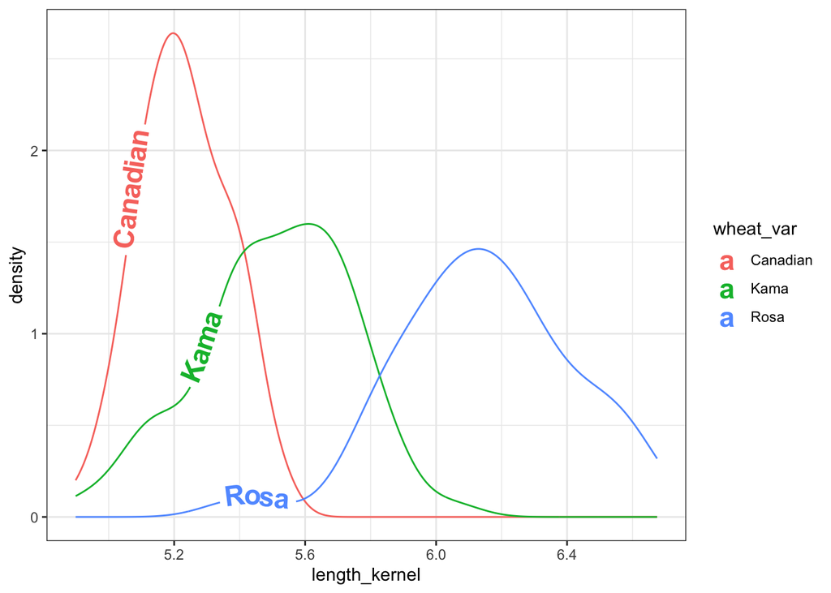

Density plot of kernel length of three wheat varieties

```r
library(ggplot2)
library(geomtextpath)

ggplot(wht_data, aes(x = length_kernel, colour = wheat_var, label = wheat_var)) +
  geom_textdensity(size = 6, fontface = 2, hjust = 0.2, vjust = 0.3) +
  theme(legend.position = "none") + theme_bw()
```

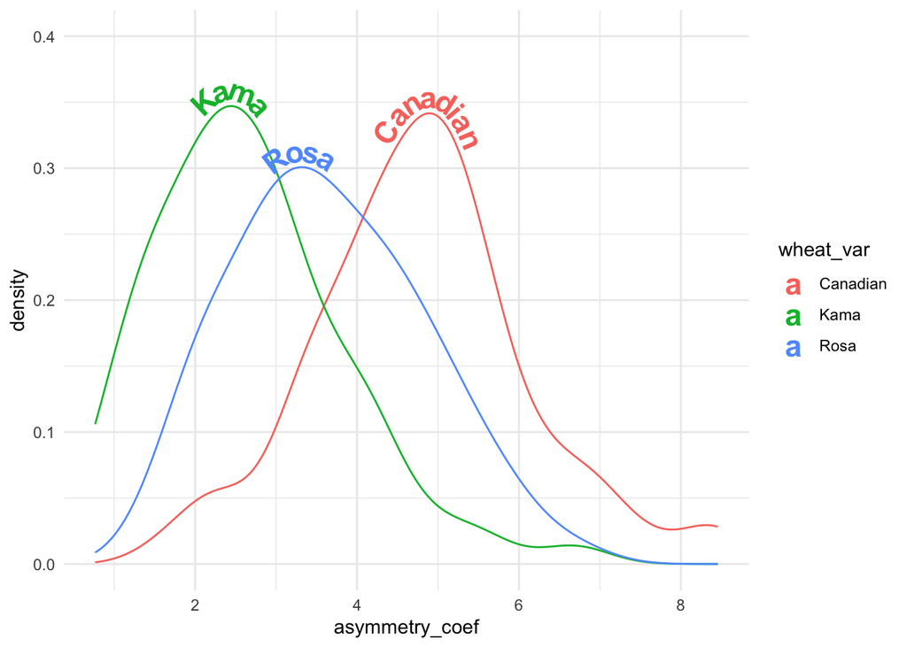

Density plot of asymmetry coefficient of three wheat varieties

```r
library(ggplot2)
library(geomtextpath)
ggplot(wht_data, aes(x = asymmetry_coef, colour = wheat_var,
                     label = wheat_var)) +
       theme(legend.position = "none") +
       geom_textdensity(size = 6, fontface = 2, spacing = 50,
                   vjust = -0.2, hjust = "ymax") + ylim(c(0, 0.4)) + theme_minimal()
```

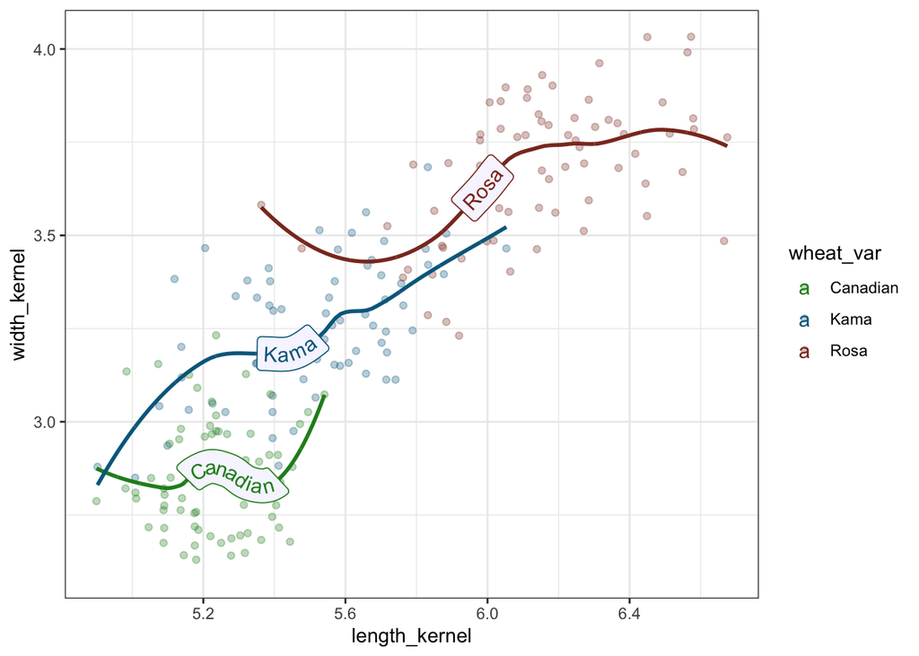

Trend Lines through scatter plot of length and width of wheat varieties

```r
ggplot(wht_data, aes(x = length_kernel, y = width_kernel,
                     color = wheat_var)) +
  geom_point(alpha = 0.3) + theme(legend.position = "bottom") +
  geom_labelsmooth(aes(label = wheat_var), text_smoothing = 30,
                   fill = "#F6F6FF",
                method = "loess", formula = y ~ x,
                size = 4, linewidth = 1, boxlinewidth = 0.3) +
  scale_colour_manual(values = c("forestgreen", "deepskyblue4", "tomato4")) +
   theme_bw()
```

### Correlation Pairs

The correlation plot shown below reveal that there is multicollinearity problem. To deal with multicollinearity, there are a couple of solutions, including 1) removing one of the features from the highly correlated feature combinations, 2) linearly combine the variables using principal component analysis or partial least squares. In this case, I will use the first option to remove `perimeter`, `length_kernel`, and `width_kernel` features.

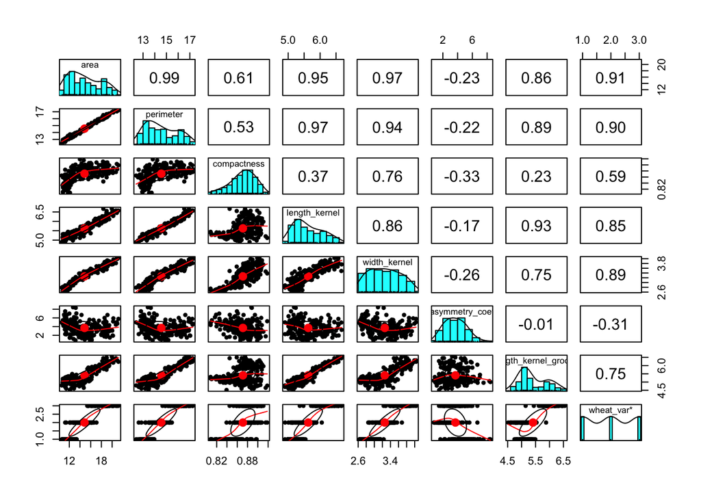

```r
library(psych)
pairs.panels(wht_data)
```

The correlation pairs plot after removing the above mentioned features is shown below.

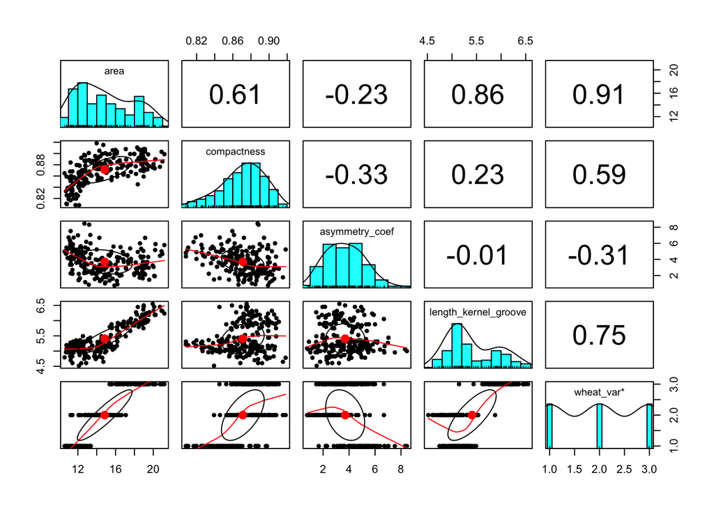

```r
library(psych)
library(tidyverse)
wht_data <- wht_data %>%
  select(!c(perimeter, length_kernel, width_kernel))

pairs.panels(wht_data)
```

### Near-zero variance features

```r
library(caret)
near_0_var <- nearZeroVar(wht_data, names = TRUE)
print(near_0_var)
```

```
## character(0)
```

The result indicate that there are no zero variance features, which is good. Therefore, we can use all the features to predict the the class of wheat variety.

### Checking for class imbalance

It was already known that there are equal observations for each of the wheat varieties in our dataset. That is, each variety has 70 observations for a total of 210 observations. Therefore, our data set do not suffer with class imbalance problem.

```r
table(wht_data$wheat_var)
```

```
##
## Canadian     Kama     Rosa
##       70       70       70
```

## Ensemble Models

### Splitting the data

```r
library(caret)

set.seed(4321)
wht_data$wheat_var <- as.factor(wht_data$wheat_var)
in_train <- createDataPartition(y = wht_data$wheat_var,
                                p = 0.80, list = FALSE)

training <- wht_data[in_train,]
testing <- wht_data[-in_train,]

table(training$wheat_var)
```

```
##
## Canadian     Kama     Rosa
##       56       56       56
```

```r
table(testing$wheat_var)
```

```
##
## Canadian     Kama     Rosa
##       14       14       14
```

```r
head(training)
```

```
##    area compactness asymmetry_coef length_kernel_groove wheat_var
## 2 14.88      0.8811          1.018                4.956      Kama
## 3 14.29      0.9050          2.699                4.825      Kama
## 4 13.84      0.8955          2.259                4.805      Kama
## 5 16.14      0.9034          1.355                5.175      Kama
## 7 14.69      0.8799          3.586                5.219      Kama
## 8 14.11      0.8911          2.700                5.000      Kama
```

```r
str(training)
```

```
## 'data.frame':    168 obs. of  5 variables:
##  $ area                : num  14.9 14.3 13.8 16.1 14.7 ...
##  $ compactness         : num  0.881 0.905 0.895 0.903 0.88 ...
##  $ asymmetry_coef      : num  1.02 2.7 2.26 1.35 3.59 ...
##  $ length_kernel_groove: num  4.96 4.83 4.8 5.17 5.22 ...
##  $ wheat_var           : Factor w/ 3 levels "Canadian","Kama",..: 2 2 2 2 2 2 2 2 2 2 ...
```

### Hyperparameter Tuning

In the case of Random Forest model, number of features selected in `mtry` for constructing decision trees (or more specifically at each split) is probably the most important tuning parameter.

#### Random Search for Randomly Selecting Predictors (mtry)

```r
modelLookup("rf")
```

```
##   model parameter                         label forReg forClass probModel
## 1    rf      mtry #Randomly Selected Predictors   TRUE     TRUE      TRUE
```

```r
library(caret)

fitControl <- trainControl(method = "repeatedcv",
                            number = 5, repeats = 5,
                           search = 'random')

#manual_grid_rf <- expand.grid(#n.trees = c(100, 200, 500, 750, 1000),
#                         #interaction.depth = c(1, 4, 6),
#                         #shrinkage = 0.1,
#                         #n.minobsinnode = 10,
#                         .mtry = c(1:5))
set.seed(143)
library(tictoc)
tic()

model_rf_random <- train(wheat_var ~.,
                         data = training,
                         method = "rf",
                         metric = 'Accuracy',
                         trControl = fitControl,
                         verbose = FALSE,
                         tuneLength = 4)
toc()
```

```
## 3.264 sec elapsed
```

```r
print(model_rf_random)
```

```
## Random Forest
##
## 168 samples
##   4 predictor
##   3 classes: 'Canadian', 'Kama', 'Rosa'
##
## No pre-processing
## Resampling: Cross-Validated (5 fold, repeated 5 times)
## Summary of sample sizes: 134, 134, 135, 135, 134, 135, ...
## Resampling results across tuning parameters:
##
##   mtry  Accuracy   Kappa
##   1     0.9357494  0.9035902
##   4     0.9250522  0.8875511
##
## Accuracy was used to select the optimal model using the largest value.
## The final value used for the model was mtry = 1.
```

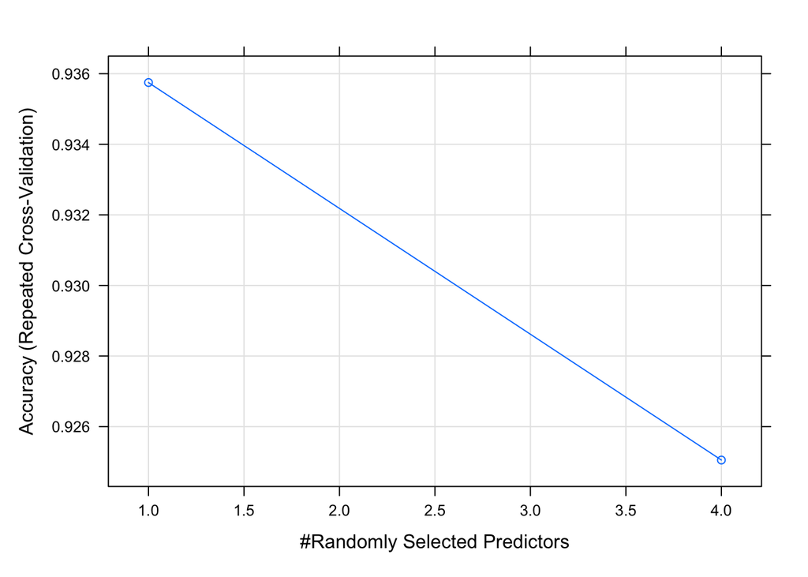

```r
plot(model_rf_random)
```

#### Grid Search for Selecting Optimal mtry

```r
fitControl <- trainControl(method = "repeatedcv",
                            number = 3, repeats = 5,
                           search = 'grid')

tunegrid <- expand.grid(.mtry = (1:4))

model_rf_grid <- train(wheat_var ~.,
                       data = training,
                       method = 'rf',
                       metric = 'Accuracy',
                       tuneGrid = tunegrid)
print(model_rf_grid)
```

```
## Random Forest
##
## 168 samples
##   4 predictor
##   3 classes: 'Canadian', 'Kama', 'Rosa'
##
## No pre-processing
## Resampling: Bootstrapped (25 reps)
## Summary of sample sizes: 168, 168, 168, 168, 168, 168, ...
## Resampling results across tuning parameters:
##
##   mtry  Accuracy   Kappa
##   1     0.9247728  0.8865813
##   2     0.9224229  0.8830108
##   3     0.9205031  0.8800244
##   4     0.9187102  0.8773807
##
## Accuracy was used to select the optimal model using the largest value.
## The final value used for the model was mtry = 1.
```

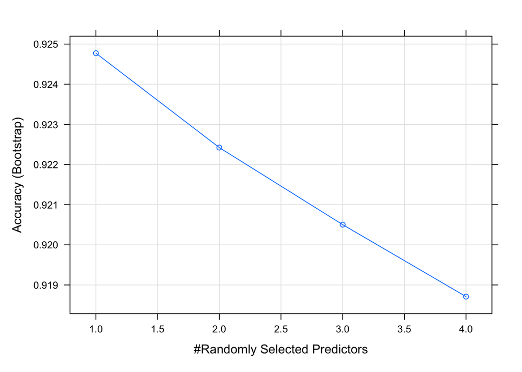

```r
plot(model_rf_grid)
```

The grid search and random search suggest same `mtry` values in this case. Generally, grid search is considered as accurate as it evaluates all the combinations in the proposed Cartesian grid. Therefore, for modeling random forest model, `mtry = 1` was used for the final model (shown later).

```r
library(caret)
manual_grid <- expand.grid(n.trees = c(100, 200, 500),
                         interaction.depth = c(1, 4, 6),
                         shrinkage = 0.1,
                         n.minobsinnode = 10)

fitControl <- trainControl(method = "repeatedcv",
                            number = 3, repeats = 5)
library(tictoc)
tic()
set.seed(123)
model_gbm_grid <- train(wheat_var ~.,
                         data = training,
                         method = "gbm",
                         trControl = fitControl,
                         verbose = FALSE,
                         tuneGrid = manual_grid)
toc()
```

```
## 3.528 sec elapsed
```

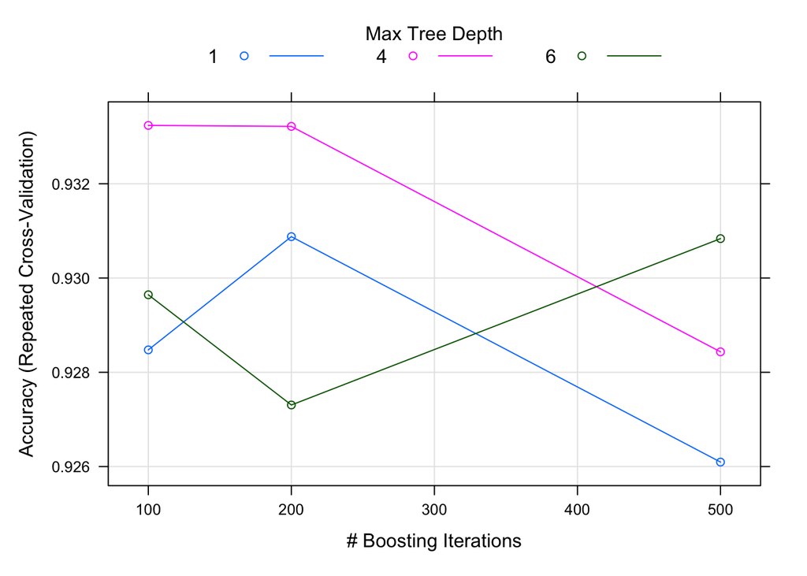

```r
plot(model_gbm_grid)
```

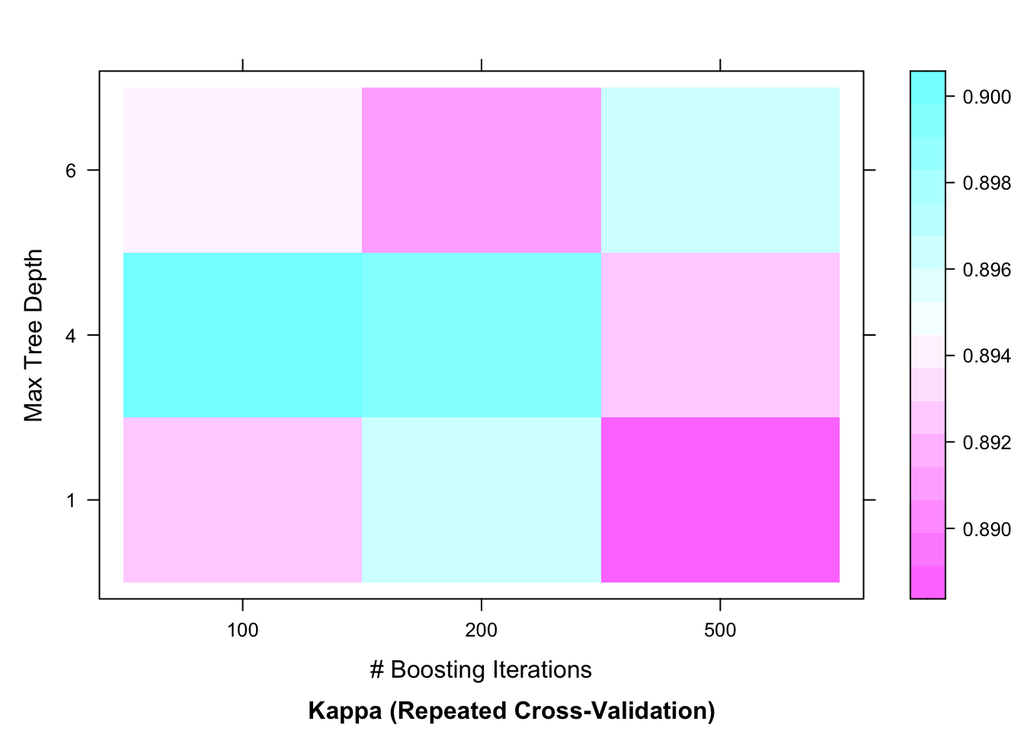

```r
plot(model_gbm_grid,
     metric = "Kappa",
     plotType = "level")
```

The plots of gradient boosting model reveal that maximum accuracy is achieved when the number of trees are set at 100 with the tree depth (interaction.depth) at 4.

### Classification: Random Forest

```r
### load the randomForest package
library(randomForest)
set.seed(123)
### train the random forest model: model_rf
model_rf <- randomForest(formula = wheat_var ~.,
                         data = training,
                         ntree = 300,
                         mtry = 1)

### print the rf model
print(model_rf)
```

```
##
## Call:
##  randomForest(formula = wheat_var ~ ., data = training, ntree = 300,      mtry = 1)
##                Type of random forest: classification
##                      Number of trees: 300
## No. of variables tried at each split: 1
##
##         OOB estimate of  error rate: 7.14%
## Confusion matrix:
##          Canadian Kama Rosa class.error
## Canadian       52    4    0  0.07142857
## Kama            6   50    0  0.10714286
## Rosa            0    2   54  0.03571429
```

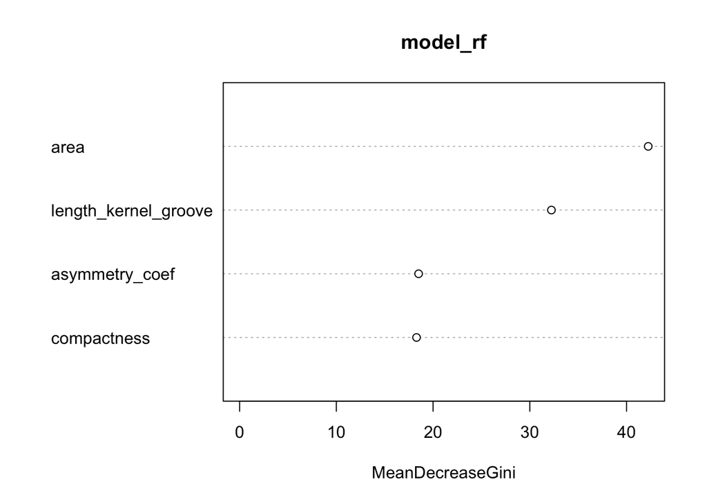

```r
### variable importance plots
varImpPlot(model_rf)
```

```r
print(model_rf$importance)
```

```
##                      MeanDecreaseGini
## area                         42.23948
## compactness                  18.28924
## asymmetry_coef               18.50317
## length_kernel_groove         32.23213
```

### Classification : Gradient Boosting Model

```r
### load the gradient boosting model package
library(gbm)
set.seed(143)
### train the gradient boosting model: model_gbm
model_gbm <- gbm(formula = wheat_var ~.,
                         data = training,
                         n.trees = 100,
                         interaction.depth = 4,
                         shrinkage = 0.1,
                         n.minobsinnode = 10)
```

```
## Distribution not specified, assuming multinomial ...
```

```r
### print the gbm model
print(model_gbm)
```

```
## gbm(formula = wheat_var ~ ., data = training, n.trees = 100,
##     interaction.depth = 4, n.minobsinnode = 10, shrinkage = 0.1)
## A gradient boosted model with multinomial loss function.
## 100 iterations were performed.
## There were 4 predictors of which 4 had non-zero influence.
```

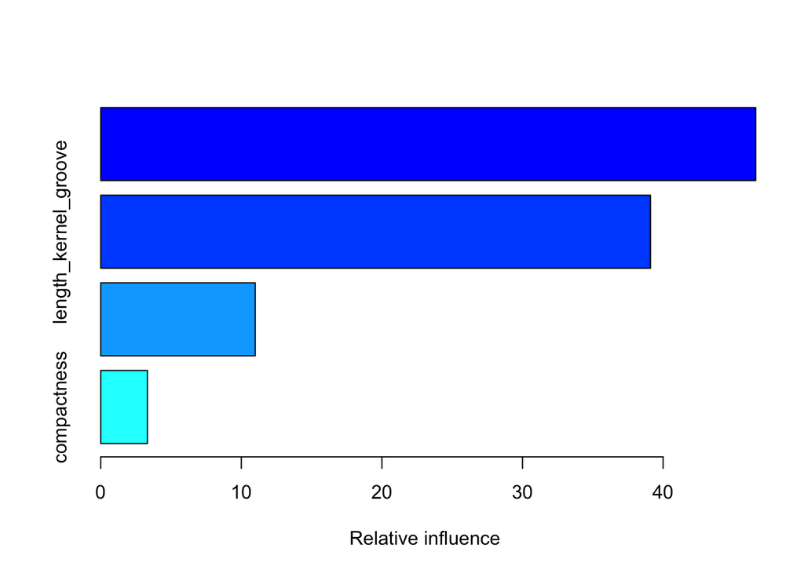

```
##                                       var   rel.inf
## area                                 area 46.589280
## length_kernel_groove length_kernel_groove 39.100031
## asymmetry_coef             asymmetry_coef 10.990146
## compactness                   compactness  3.320543
```

```r
### summarize gbm's variable importance plots
summary(model_gbm)
```

### Evaluating both Random Forest and Gradient Boosting Algorithms

```r
library(Metrics)

preds_rf <- predict(model_rf, newdata = testing)
preds_gbm <- predict(model_gbm, n.trees = 100, newdata = testing, type = "response")
## compute confusion matrix



classes <- colnames(preds_gbm)[apply(preds_gbm, 1, which.max)]
result_gbm <- data.frame(testing$wheat_var, classes)

#print(result_gbm)
(cm_rf <- confusionMatrix(preds_rf, testing$wheat_var))
```

```
## Confusion Matrix and Statistics
##
##           Reference
## Prediction Canadian Kama Rosa
##   Canadian       13    0    0
##   Kama            1   12    0
##   Rosa            0    2   14
##
## Overall Statistics
##
##                Accuracy : 0.9286
##                  95% CI : (0.8052, 0.985)
##     No Information Rate : 0.3333
##     P-Value [Acc > NIR] : 8.716e-16
##
##                   Kappa : 0.8929
##
##  Mcnemar's Test P-Value : NA
##
## Statistics by Class:
##
##                      Class: Canadian Class: Kama Class: Rosa
## Sensitivity                   0.9286      0.8571      1.0000
## Specificity                   1.0000      0.9643      0.9286
## Pos Pred Value                1.0000      0.9231      0.8750
## Neg Pred Value                0.9655      0.9310      1.0000
## Prevalence                    0.3333      0.3333      0.3333
## Detection Rate                0.3095      0.2857      0.3333
## Detection Prevalence          0.3095      0.3095      0.3810
## Balanced Accuracy             0.9643      0.9107      0.9643
```

```r
(cm_gbm <- confusionMatrix(as.factor(classes), testing$wheat_var))
```

```
## Confusion Matrix and Statistics
##
##           Reference
## Prediction Canadian Kama Rosa
##   Canadian       13    0    0
##   Kama            1   12    0
##   Rosa            0    2   14
##
## Overall Statistics
##
##                Accuracy : 0.9286
##                  95% CI : (0.8052, 0.985)
##     No Information Rate : 0.3333
##     P-Value [Acc > NIR] : 8.716e-16
##
##                   Kappa : 0.8929
##
##  Mcnemar's Test P-Value : NA
##
## Statistics by Class:
##
##                      Class: Canadian Class: Kama Class: Rosa
## Sensitivity                   0.9286      0.8571      1.0000
## Specificity                   1.0000      0.9643      0.9286
## Pos Pred Value                1.0000      0.9231      0.8750
## Neg Pred Value                0.9655      0.9310      1.0000
## Prevalence                    0.3333      0.3333      0.3333
## Detection Rate                0.3095      0.2857      0.3333
## Detection Prevalence          0.3095      0.3095      0.3810
## Balanced Accuracy             0.9643      0.9107      0.9643
```

## Conclusions

The ensemble models suggest that there is an accuracy of about 93% in case of both Random Forest and GBM predicting the correct wheat variety using a set of features. Variable importance plot results of both the models show that area (highest importantance), length of kernel groove, asymmetry coefficient, and compactness (lowest importance) play an important role in wheat variety prediction. in case of both the models. Overall, both the models show consistent results and agree with each other.

In the UC Irvine’s data repository, it was indicated that there was some critical features that they could not provide due to proprietary issues associated with those data. Therefore, given those additional features, there is a scope for improving accuracy rate. Overall, the classification results show that accuracy of predicting the correct wheat variety is high.